# Notebook 17 – Solutions

## Getting Started

Before running this notebook, select “Session > Restart R and Clear Output” in the menu above to start a new R session. This will clear any old data sets and give us a blank slate to start with.

## Comics

Today we are going to look at a dataset describing the long-running comic series Peanuts. I have been building this for a research project with Lauren Tilton and Justin Wigard and we thought it would be fun to have you all take a look at something we are currently working on.

We have one table with one row for each Peanuts comics. The last two columns describe the size of the scanned image of the comic in pixels.

```r
comics <- read_csv("../data/comics_meta.csv.bz2")
comics
```

```
## # A tibble: 17,943 × 6
##    image_path                    feature_name creator date        nrow  ncol
##    <chr>                         <chr>        <chr>   <date>     <dbl> <dbl>
##  1 3acf4280f867013014ce001dd8b7… Peanuts      Charle… 1950-10-02   181   900
##  2 3b3252f0f867013014ce001dd8b7… Peanuts      Charle… 1950-10-03   180   900
##  3 3b909930f867013014ce001dd8b7… Peanuts      Charle… 1950-10-04   181   900
##  4 3bf3feb0f867013014ce001dd8b7… Peanuts      Charle… 1950-10-05   179   900
##  5 3c5a6780f867013014ce001dd8b7… Peanuts      Charle… 1950-10-06   180   900
##  6 3cbd0e70f867013014ce001dd8b7… Peanuts      Charle… 1950-10-07   182   900
##  7 3d1b9f10f867013014ce001dd8b7… Peanuts      Charle… 1950-10-09   179   900
##  8 3d7b70b0f867013014ce001dd8b7… Peanuts      Charle… 1950-10-10   182   900
##  9 3ddfb9f0f867013014ce001dd8b7… Peanuts      Charle… 1950-10-11   181   900
## 10 3e4cabc0f867013014ce001dd8b7… Peanuts      Charle… 1950-10-12   186   900
## # ℹ 17,933 more rows
```

We have another dataset that was automatically generated using a computer vision algorithm. This one describes all of the panels that were detected in each comic strip.

```r
panels <- read_csv("../data/comics_panels.csv.bz2")
panels
```

```
## # A tibble: 81,649 × 6
##    image_path                           panel_id  xmin  xmax  ymin  ymax
##    <chr>                                   <dbl> <dbl> <dbl> <dbl> <dbl>
##  1 3acf4280f867013014ce001dd8b71c47.jpg        1     6   223     6   174
##  2 3acf4280f867013014ce001dd8b71c47.jpg        2   229   446     6   173
##  3 3acf4280f867013014ce001dd8b71c47.jpg        3   452   670     5   173
##  4 3acf4280f867013014ce001dd8b71c47.jpg        4   675   893     5   173
##  5 3b3252f0f867013014ce001dd8b71c47.jpg        1     6   222     6   174
##  6 3b3252f0f867013014ce001dd8b71c47.jpg        2   229   446     6   174
##  7 3b3252f0f867013014ce001dd8b71c47.jpg        3   452   669     6   174
##  8 3b3252f0f867013014ce001dd8b71c47.jpg        4   676   894     6   174
##  9 3b909930f867013014ce001dd8b71c47.jpg        1     7   223     6   173
## 10 3b909930f867013014ce001dd8b71c47.jpg        2   230   446     6   173
## # ℹ 81,639 more rows
```

Finally, we have another automatically created datsets of comic captions. These describe all of the locations in the comic where our computer vision algorithm detected text.

```r
captions <- read_csv("../data/comics_captions.csv.bz2")
captions
```

```
## # A tibble: 291,584 × 7
##    image_path                 xmid  ymid xmin_cap xmax_cap ymin_cap ymax_cap
##    <chr>                     <dbl> <dbl>    <dbl>    <dbl>    <dbl>    <dbl>
##  1 3acf4280f867013014ce001d…    49   160       31       67      168      152
##  2 3acf4280f867013014ce001d…   119   160       77      161      168      152
##  3 3acf4280f867013014ce001d…   297   159      267      327      166      152
##  4 3acf4280f867013014ce001d…   358   159      331      385      166      152
##  5 3acf4280f867013014ce001d…   547   158      487      607      166      150
##  6 3acf4280f867013014ce001d…   732   157      717      747      164      150
##  7 3acf4280f867013014ce001d…   111   146       61      161      154      138
##  8 3acf4280f867013014ce001d…   291   146      267      315      154      138
##  9 3acf4280f867013014ce001d…   353   146      325      381      154      138
## 10 3acf4280f867013014ce001d…   533   145      509      557      152      138
## # ℹ 291,574 more rows
```

### Understanding the data

To start, take the `comics` data, filter to just include the single comic whose path is “8178d1c0fbb20130177f001dd8b71c47.jpg”, and do an inner join to the `panels` data. This will show all of the detected panels for this one comic, of which there should be 10.

```r
# Question 01
comics |>
  filter(image_path == "8178d1c0fbb20130177f001dd8b71c47.jpg") |>
  inner_join(panels, by = "image_path")
```

```
## # A tibble: 10 × 11
##    image_path     feature_name creator date        nrow  ncol panel_id  xmin
##    <chr>          <chr>        <chr>   <date>     <dbl> <dbl>    <dbl> <dbl>
##  1 8178d1c0fbb20… Peanuts      Charle… 2000-01-16   606   900        1     2
##  2 8178d1c0fbb20… Peanuts      Charle… 2000-01-16   606   900        2   605
##  3 8178d1c0fbb20… Peanuts      Charle… 2000-01-16   606   900        3     2
##  4 8178d1c0fbb20… Peanuts      Charle… 2000-01-16   606   900        4   182
##  5 8178d1c0fbb20… Peanuts      Charle… 2000-01-16   606   900        5   379
##  6 8178d1c0fbb20… Peanuts      Charle… 2000-01-16   606   900        6   605
##  7 8178d1c0fbb20… Peanuts      Charle… 2000-01-16   606   900        7     3
##  8 8178d1c0fbb20… Peanuts      Charle… 2000-01-16   606   900        8   302
##  9 8178d1c0fbb20… Peanuts      Charle… 2000-01-16   606   900        9   511
## 10 8178d1c0fbb20… Peanuts      Charle… 2000-01-16   606   900       10   670
## # ℹ 3 more variables: xmax <dbl>, ymin <dbl>, ymax <dbl>
```

Now, let’s visualize these panels. Starting with the data you created in the previous code chunk, create a plot using a `geom_rect` layer. This layer requires the aesthetics `xmin`, `xmax`, `ymin`, and `ymax`; these can be set the corresponding names in the data. Set the color of the rectangles to “blue” and the alpha to 0.

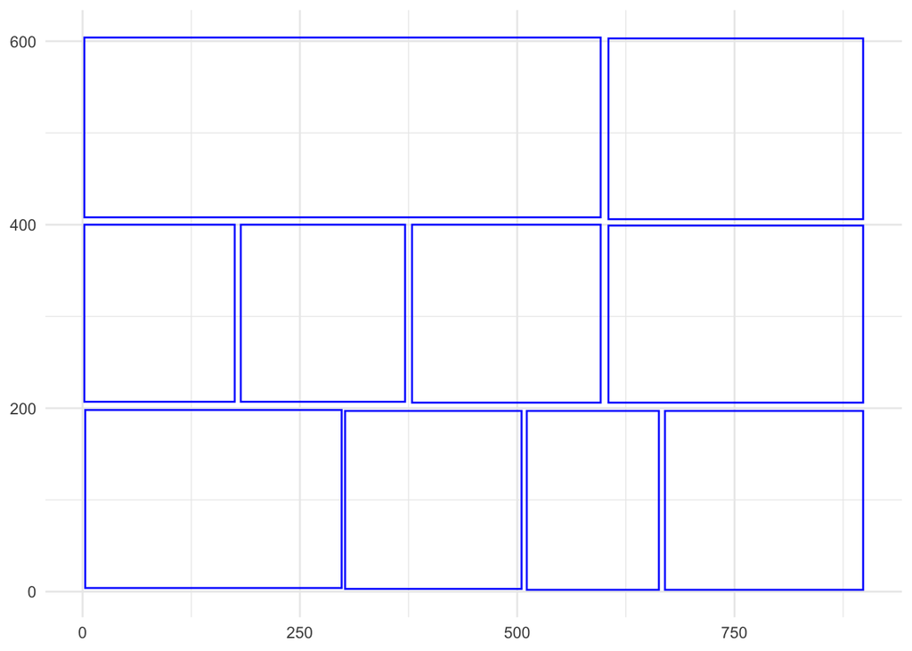

```r
# Question 02
comics |>
  filter(image_path == "8178d1c0fbb20130177f001dd8b71c47.jpg") |>
  inner_join(panels, by = "image_path") |>
  ggplot() +
    geom_rect(aes(
      xmin = xmin, xmax = xmax, ymin = ymin, ymax = ymax),
      color = "blue", alpha = 0
    )
```

The plot above should show the layout of the comic. Let’s check the output and our understanding of the data. Open the following link in a browser to see the actual comic image:

https://assets.amuniversal.com/8178d1c0fbb20130177f001dd8b71c47.jpg

Let’s take a look also at the captions. In the block below, starting with your code from the previous question, also join the `captions` data and add a `geom_point` layer showing the `xmid` and `ymid` of the captions. Go back to the comic to verify that these roughly match the text in the image.

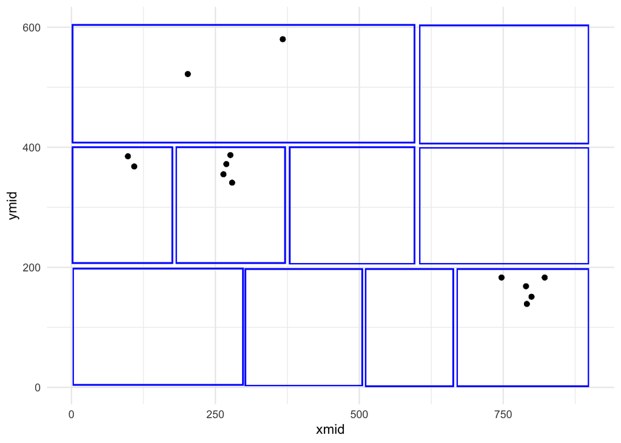

```r
# Question 03
comics |>
  filter(image_path == "8178d1c0fbb20130177f001dd8b71c47.jpg") |>
  inner_join(panels, by = "image_path") |>
  inner_join(captions, by = "image_path") |>
  ggplot() +
    geom_rect(aes(
      xmin = xmin, xmax = xmax, ymin = ymin, ymax = ymax),
      color = "blue", alpha = 0
    ) +
    geom_point(aes(xmid, ymid))
```

Finally, in the code block below, modify your previous plot by adding a `geom_text` layer that labels the panels with their `panel_id` by setting `x = (xmin + xmax) / 2` and `y = (ymin + ymax) / 2`. This will verify that our ordering of the panels is correct.

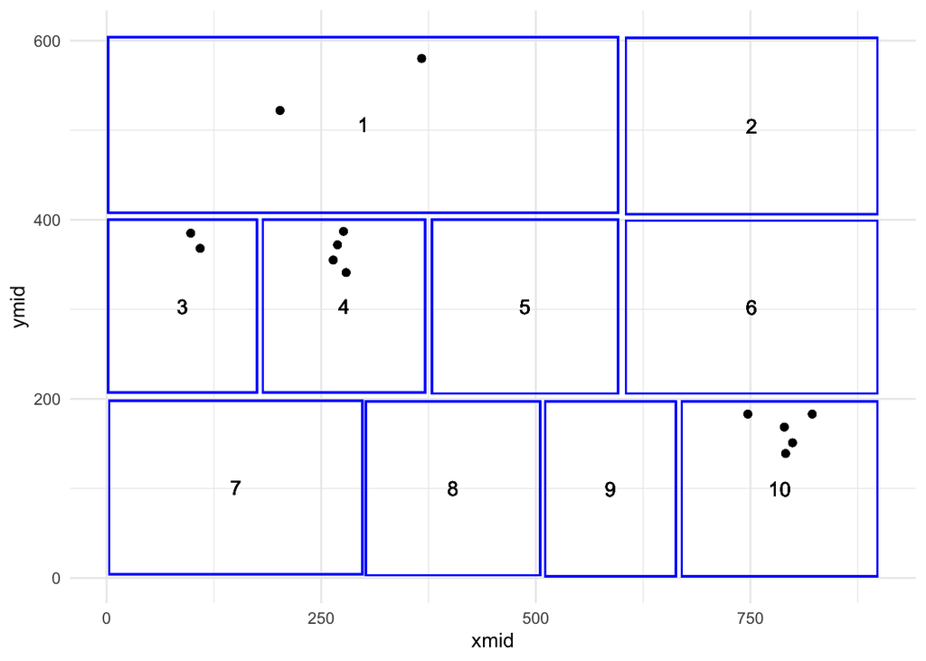

```r
# Question 04
comics |>
  filter(image_path == "8178d1c0fbb20130177f001dd8b71c47.jpg") |>
  inner_join(panels, by = "image_path") |>
  inner_join(captions, by = "image_path") |>
  ggplot() +
    geom_rect(aes(
      xmin = xmin, xmax = xmax, ymin = ymin, ymax = ymax),
      color = "blue", alpha = 0
    ) +
    geom_point(aes(xmid, ymid)) +
    geom_text(aes(x = (xmin + xmax) / 2, y = (ymin + ymax) / 2, label = panel_id))
```

Now that we understand the data through a single sample, let’s look at the collection as a whole.

### Working with Dates

In the interest of time (I really want everyone to get to the research questions today), I will help you with the next intermediate step. Here is the code to compute the total number of panels in each comic:

```r
panels_total <- panels |>
  group_by(image_path) |>
  summarize(n = n())
panels_total
```

```
## # A tibble: 17,943 × 2
##    image_path                               n
##    <chr>                                <int>
##  1 000000f0f88a013014fa001dd8b71c47.jpg     4
##  2 0002a150f87e013014e9001dd8b71c47.jpg     8
##  3 00050780f895013014ff001dd8b71c47.jpg     4
##  4 0006a270fba401301769001dd8b71c47.jpg     3
##  5 000f49e0fb8f0130174f001dd8b71c47.jpg    11
##  6 0013e460fba501301769001dd8b71c47.jpg     3
##  7 00168790fb8901301747001dd8b71c47.jpg     4
##  8 00172c30fb9f01301763001dd8b71c47.jpg     3
##  9 001735d0f88c013014fa001dd8b71c47.jpg     4
## 10 001ad480f893013014ff001dd8b71c47.jpg     4
## # ℹ 17,933 more rows
```

For the next question, join the `panels_total` data to the `comics` data and compute the day of the week of the comic. Set `label = TRUE` to see the weekday names. Summarize the data to determine the average number of panels for each day of the week. You should see that most days are indistinguishable, except for Sunday, which is much longer.

```r
# Question 05
panels_total |>
  inner_join(comics, by = "image_path") |>
  mutate(wday = wday(date, label = TRUE)) |>
  group_by(wday) |>
  summarize(n = mean(n))
```

```
## # A tibble: 7 × 2
##   wday      n
##   <ord> <dbl>
## 1 Mon    3.71
## 2 Tue    3.75
## 3 Wed    3.78
## 4 Thu    3.77
## 5 Fri    3.76
## 6 Sat    3.72
## 7 Sun    9.49
```

Now, draw a plot with one point for each comic from the year 1995. For each point, set the x-aesthetic to be the date and the y-aesthetic to by the number of panels. Color the points by the day of the week.

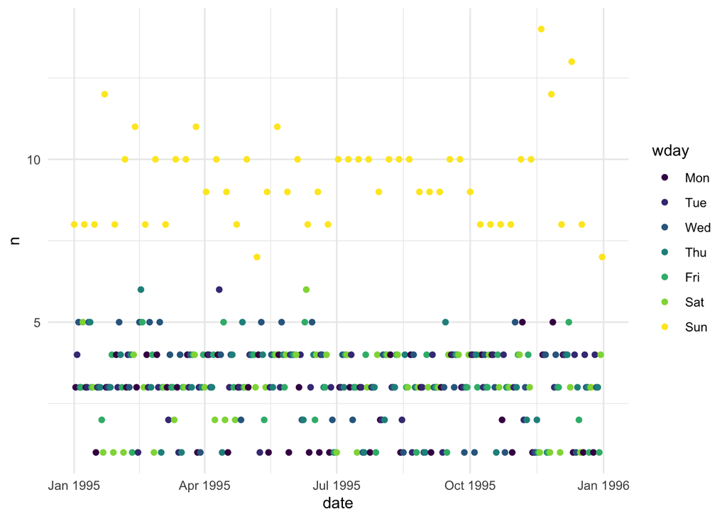

```r
# Question 06
panels_total |>
  inner_join(comics, by = "image_path") |>
  mutate(wday = wday(date, label = TRUE)) |>
  filter(year(date) == 1995) |>
  ggplot(aes(date, n)) +
    geom_point(aes(color = wday))
```

In the code block below, modify your previous plot to have one label on the x-axis for each month and make the label equal to the month abbreviation.

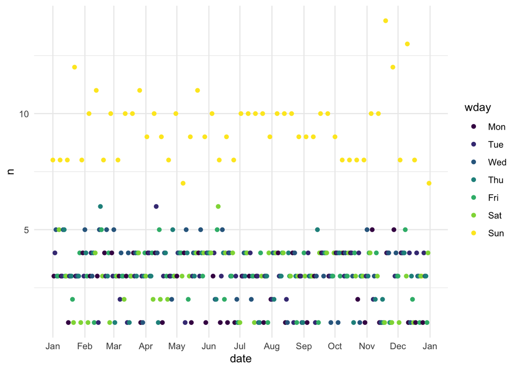

```r
# Question 07
panels |>
  group_by(image_path) |>
  summarize(n = n()) |>
  inner_join(comics, by = "image_path") |>
  mutate(wday = wday(date, label = TRUE)) |>
  filter(year(date) == 1995) |>
  ggplot(aes(date, n)) +
    geom_point(aes(color = wday)) +
    scale_x_date(breaks = "1 month", date_labels = "%b", minor_breaks = "1 month")
```

### Research Question: Last Panel Captions

In this last section, we will try to look at one of the research questions we have about this data. Usually, the punchline of a comic comes in the last panel. This can be a verbal punchline, but can also be a punchline described through the visual message. We’d like to understand when and how often the final panel contains a caption in order to understand how often each type of punchline gets used. Let’s try to do this with the techniques we’ve learned so far!

To start, two hints to speed things along. First, notice that the following code (the fairly rare grouped filter) gives us all of the final panels in the data:

```r
panels |>
  group_by(image_path) |>
  filter(panel_id == max(panel_id)) |>
  ungroup()
```

```
## # A tibble: 17,943 × 6
##    image_path                           panel_id  xmin  xmax  ymin  ymax
##    <chr>                                   <dbl> <dbl> <dbl> <dbl> <dbl>
##  1 3acf4280f867013014ce001dd8b71c47.jpg        4   675   893     5   173
##  2 3b3252f0f867013014ce001dd8b71c47.jpg        4   676   894     6   174
##  3 3b909930f867013014ce001dd8b71c47.jpg        4   676   892     6   173
##  4 3bf3feb0f867013014ce001dd8b71c47.jpg        4   677   894     5   173
##  5 3c5a6780f867013014ce001dd8b71c47.jpg        4   675   893     6   175
##  6 3cbd0e70f867013014ce001dd8b71c47.jpg        4   676   894     6   174
##  7 3d1b9f10f867013014ce001dd8b71c47.jpg        4   675   893     5   173
##  8 3d7b70b0f867013014ce001dd8b71c47.jpg        4   676   894     5   173
##  9 3ddfb9f0f867013014ce001dd8b71c47.jpg        4   674   892     6   173
## 10 3e4cabc0f867013014ce001dd8b71c47.jpg        4   671   886    11   178
## # ℹ 17,933 more rows
```

Secondly, the following summary function, when put into a pipe with all of the variable, will tell us the proportion of final panels that contain some caption in them. This is a bit complicated because we need to ignore “captions” at the bottom of the final panel, because this is often where the date or creator’s signature appears.

```
  summarize(
    last_caption = 100 * as.numeric(any((xmid >= xmin & xmid <= xmax) &
                                        (ymid >= (ymin * 0.3 + ymax * 0.7) &
                                        ymid <= ymax))))
```

For the next question, put together the two hints above to create a dataset with one row for each comic with a column `last_caption` equal to 0 if the comic does not have a caption in the final panel and 100 if it does.

```r
# Question 08
panels |>
  group_by(image_path) |>
  filter(panel_id == max(panel_id)) |>
  ungroup() |>
  inner_join(captions, by = "image_path") |>
  group_by(image_path) |>
  summarize(
    last_caption = 100 * as.numeric(any((xmid >= xmin & xmid <= xmax) &
                                        (ymid >= (ymin * 0.3 + ymax * 0.7) &
                                        ymid <= ymax))))
```

```
## # A tibble: 17,943 × 2
##    image_path                           last_caption
##    <chr>                                       <dbl>
##  1 000000f0f88a013014fa001dd8b71c47.jpg          100
##  2 0002a150f87e013014e9001dd8b71c47.jpg            0
##  3 00050780f895013014ff001dd8b71c47.jpg          100
##  4 0006a270fba401301769001dd8b71c47.jpg          100
##  5 000f49e0fb8f0130174f001dd8b71c47.jpg            0
##  6 0013e460fba501301769001dd8b71c47.jpg          100
##  7 00168790fb8901301747001dd8b71c47.jpg          100
##  8 00172c30fb9f01301763001dd8b71c47.jpg          100
##  9 001735d0f88c013014fa001dd8b71c47.jpg          100
## 10 001ad480f893013014ff001dd8b71c47.jpg            0
## # ℹ 17,933 more rows
```

Now, in the next block, modify your code from before to group the data by the `panel_id` and compute the average proportion of comics that have a caption in the final panel based on the total number of panels. Create a plot to visualize the relationship.

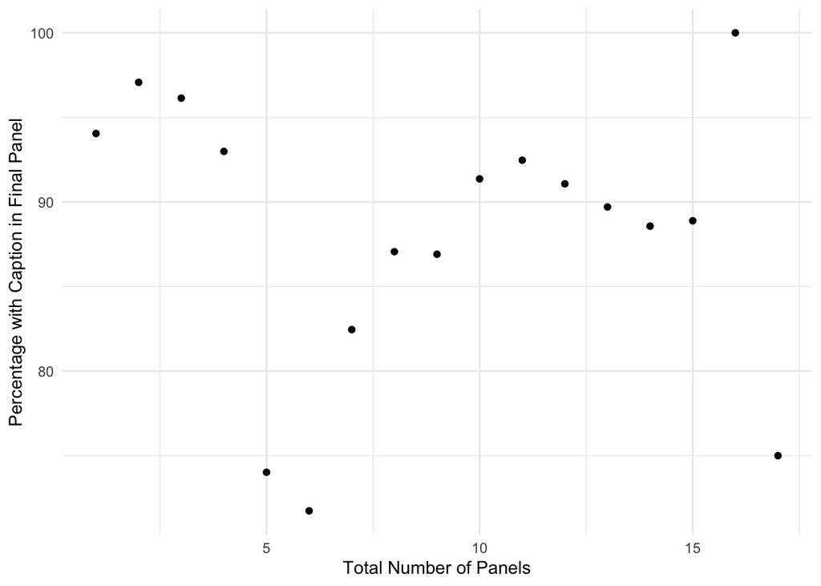

```r
# Question 09
panels |>
  group_by(image_path) |>
  filter(panel_id == max(panel_id)) |>
  ungroup() |>
  inner_join(captions, by = "image_path") |>
  group_by(panel_id, image_path) |>
  summarize(
    last_caption = 100 * as.numeric(any((xmid >= xmin & xmid <= xmax) &
                                        (ymid >= (ymin * 0.3 + ymax * 0.7) &
                                         ymid <= ymax)))) |>
  summarize(mu = mean(last_caption)) |>
  ggplot(aes(panel_id, mu)) +
    geom_point() +
    labs(x = "Total Number of Panels",
         y = "Percentage with Caption in Final Panel")
```

Finally, compute the proportion of comics with with a caption in the final panel as a function of the year of the comic.

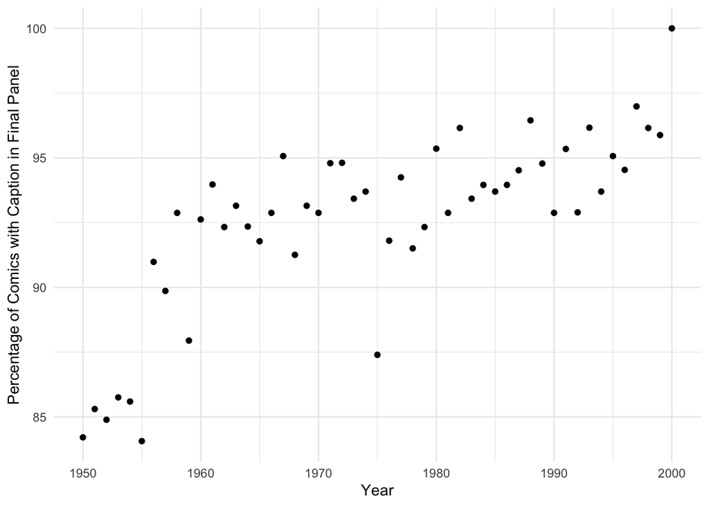

```r
# Question 10
panels |>
  group_by(image_path) |>
  filter(panel_id == max(panel_id)) |>
  ungroup() |>
  inner_join(captions, by = "image_path") |>
  group_by(image_path) |>
  summarize(
    last_caption = 100 * as.numeric(any((xmid >= xmin & xmid <= xmax) &
                                        (ymid >= (ymin * 0.3 + ymax * 0.7) &
                                        ymid <= ymax)))) |>
  inner_join(comics, by = "image_path") |>
  mutate(year = year(date)) |>
  group_by(year) |>
  summarize(mu = mean(last_caption)) |>
  ggplot(aes(year, mu)) +
    geom_point() +
    labs(x = "Year",
         y = "Percentage of Comics with Caption in Final Panel")
```